# Compulsory Assignment, BAN404

Author

William Eide and Mathias Haaland-Jensen

Published

March 22, 2026

**Introduction and Setup**: Here we include the code for running the set up for use of packages later.

**AI declaration**: During this assignment, GitHub Copilot was used as a learning tool to help understand statistical concepts, to troubleshoot errors when trying to write code, and as a conversational partner to discuss and help us understnad the theoretical implications of the bias-variance trade-off and model performance. It was also used to help the yaml formatting code of the qmd document to get the visual layout we wanted.

```python
import pandas as pd
import numpy as np
import matplotlib.pyplot as plt
import seaborn as sns # Adding seaborn for nicer plots
from sklearn.model_selection import train_test_split, KFold, cross_val_score
from sklearn.preprocessing import StandardScaler
from sklearn.linear_model import LinearRegression
from sklearn.neighbors import KNeighborsRegressor
from sklearn.tree import DecisionTreeRegressor
from sklearn.pipeline import Pipeline

np.random.seed(123)

# Load data
data = pd.read_csv("datasets/day.csv")
X = data.drop(columns=["cnt"])
y = data["cnt"]
```

# 1 Task 1

**Question**: *Describe relevant features of the output variable cnt using descriptive statistics, tables, and graphs. Use descriptive analysis to investigate which predictors appear promising for predicting daily bike rentals. Remove variables that cannot reasonably be assumed to be available at the time a prediction is made, and briefly justify your choices.*

## 1.1 Descriptive Features of the Output Variable (`cnt`)

First, we investigate the distribution and summary statistics of our response variable, `cnt` (total daily bike rentals). Understanding the distribution of the target variable is a crucial first step in any regression problem.

|  | count | mean | std | min | 25% | 50% | 75% | max |
| --- | --- | --- | --- | --- | --- | --- | --- | --- |
| cnt | 731.0 | 4504.348837 | 1937.211452 | 22.0 | 3152.0 | 4548.0 | 5956.0 | 8714.0 |

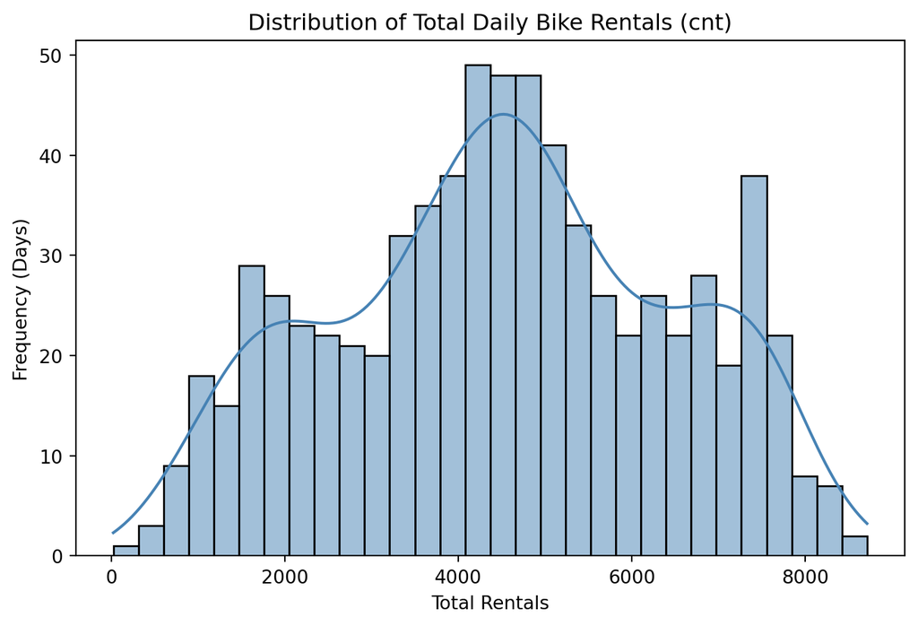

```python
# Summary statistics for the response variable
display(data['cnt'].describe().to_frame().T)

# Plotting the distribution of 'cnt'
plt.figure(figsize=(8, 5))
sns.histplot(data['cnt'], bins=30, kde=True, color='steelblue')
plt.title('Distribution of Total Daily Bike Rentals (cnt)')
plt.xlabel('Total Rentals')
plt.ylabel('Frequency (Days)')
plt.show()
```

The summary statistics show a mean of 4504 rentals with a high standard deviation of 1937, indicating significant daily variation. The histogram reveals a roughly symmetric, somewhat bimodal distribution without extreme skewness.

## 1.2 Removing Unavailable and Redundant Variables

Before predicting future responses, it is vital to avoid data leakage. Data leakage occurs when a model is trained using information that would not realistically be available at the time of prediction.

Based on the README file information on the data, `casual` and `registered` sum exactly to `cnt`. Since we cannot know the number of casual or registered users before the day concludes, these variables must be removed. Furthermore, we drop `instant` as it is merely a row identifier, and `dteday` (date string) because temporal information is already captured by the numeric features `yr`, `mnth`, and `weekday`.

```python
# Drop variables that cause data leakage or are redundant
columns_to_drop = ['casual', 'registered', 'instant', 'dteday']
df_clean = data.drop(columns=columns_to_drop)

# We update our X matrix to reflect these removed variables
X = df_clean.drop(columns=['cnt'])
```

## 1.3 Investigating Promising Predictors and Collinearity

Next, we perform a descriptive analysis to identify which features show strong associations with the response variable. We use a correlation matrix to assess linearity between predictors and `cnt`, as well as to check for potential collinearity among the predictors themselves.

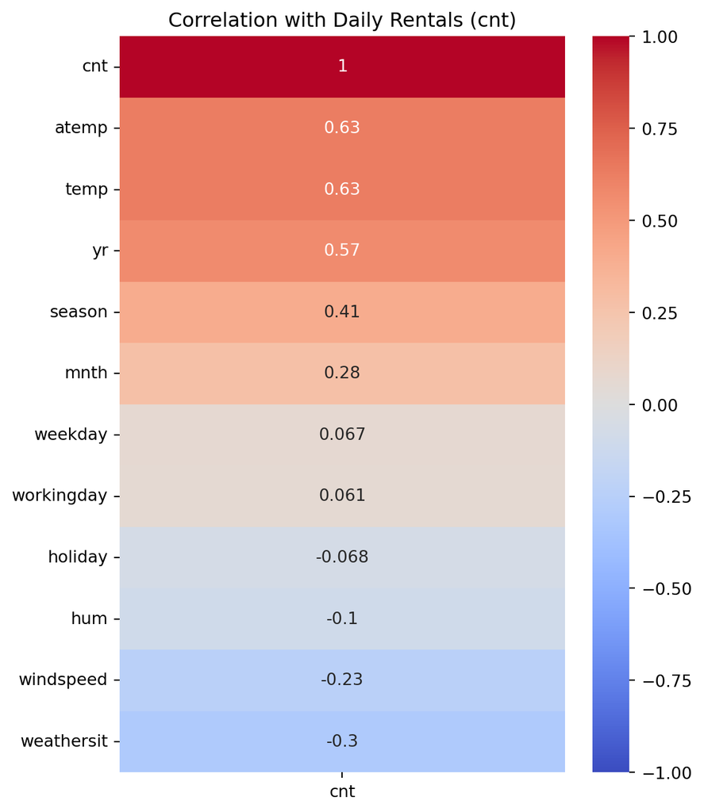

```python
# Calculate correlation matrix for the cleaned dataset
corr_matrix = df_clean.corr()

# Plot correlation of all features specifically against 'cnt'
plt.figure(figsize=(6, 8))
sns.heatmap(corr_matrix[['cnt']].sort_values(by='cnt', ascending=False),
            annot=True, cmap='coolwarm', vmin=-1, vmax=1)
plt.title('Correlation with Daily Rentals (cnt)')
plt.show()
```

Looking at the heatmap, temperature variables (`temp` and `atemp`) and the year (`yr`) show the strongest positive linear relationships with daily rentals. Conversely, weather conditions (`weathersit`), humidity (`hum`), and `windspeed` exhibit negative correlations, which is highly intuitive—worse weather reduces cycling.

We also previously noted that `temp` and `atemp` measure nearly identical phenomena (actual vs. feeling temperature). To prevent issues related to collinearity (which can inflate standard errors in linear regression models), we will drop `atemp` going forward.

```python
# Checking collinearity between temp and atemp
print(f"Correlation between temp and atemp: {df_clean['temp'].corr(df_clean['atemp']):.4f}")

# Drop atemp due to near-perfect collinearity
df_clean = df_clean.drop(columns=['atemp'])
X = df_clean.drop(columns=['cnt'])
```

```
Correlation between temp and atemp: 0.9917
```

## 1.4 Addressing Redundancy and Categorical Variables

Upon closer inspection of the remaining predictors, we note significant redundancy within the time and day-type categories. The `season` variable is redundant because the time of year is already captured more granularly by `mnth`. Similarly, `workingday` is simply a derived combination of `weekday` and `holiday`. To reduce unnecessary complexity and potential collinearity, we drop `season` and `workingday`.

Furthermore, variables like `weathersit`, `mnth`, and `weekday` are qualitative (categorical) predictors encoded as integers. As noted in statistical learning literature, treating these as continuous numeric variables in a linear regression implies a false numerical ordering (e.g., assuming month 12 is mathematically “greater” than month 6). Therefore, we convert these multi-level categorical variables into dummy variables, dropping the first level of each to avoid perfect multicollinearity (the dummy variable trap).

```python
# Drop redundant variables
df_clean = df_clean.drop(columns=['season', 'workingday'])

# Convert qualitative variables to categorical strings so pandas knows to dummy them
categorical_cols = ['weathersit', 'mnth', 'weekday']
for col in categorical_cols:
    df_clean[col] = df_clean[col].astype(str)

# Create dummy variables, dropping the first category, and force them to be 1s and 0s
df_clean = pd.get_dummies(df_clean, columns=categorical_cols, drop_first=True, dtype=int)

# Finalize our feature matrix X
X = df_clean.drop(columns=['cnt'])

print(f"Final number of predictors in X: {X.shape[1]}")
display(X.head())
```

```
Final number of predictors in X: 24
```

|  | yr | holiday | temp | hum | windspeed | weathersit_2 | weathersit_3 | mnth_10 | mnth_11 | mnth_12 | ... | mnth_6 | mnth_7 | mnth_8 | mnth_9 | weekday_1 | weekday_2 | weekday_3 | weekday_4 | weekday_5 | weekday_6 |
| --- | --- | --- | --- | --- | --- | --- | --- | --- | --- | --- | --- | --- | --- | --- | --- | --- | --- | --- | --- | --- | --- |
| 0 | 0 | 0 | 0.344167 | 0.805833 | 0.160446 | 1 | 0 | 0 | 0 | 0 | ... | 0 | 0 | 0 | 0 | 0 | 0 | 0 | 0 | 0 | 1 |
| 1 | 0 | 0 | 0.363478 | 0.696087 | 0.248539 | 1 | 0 | 0 | 0 | 0 | ... | 0 | 0 | 0 | 0 | 0 | 0 | 0 | 0 | 0 | 0 |
| 2 | 0 | 0 | 0.196364 | 0.437273 | 0.248309 | 0 | 0 | 0 | 0 | 0 | ... | 0 | 0 | 0 | 0 | 1 | 0 | 0 | 0 | 0 | 0 |
| 3 | 0 | 0 | 0.200000 | 0.590435 | 0.160296 | 0 | 0 | 0 | 0 | 0 | ... | 0 | 0 | 0 | 0 | 0 | 1 | 0 | 0 | 0 | 0 |
| 4 | 0 | 0 | 0.226957 | 0.436957 | 0.186900 | 0 | 0 | 0 | 0 | 0 | ... | 0 | 0 | 0 | 0 | 0 | 0 | 1 | 0 | 0 | 0 |

5 rows × 24 columns

# 2 Task 2

**Question**: *Use linear regression to predict cnt. Estimate at least one multiple linear regression model and one more flexible model (for example, a polynomial regression). Use the validation set approach to evaluate predictive performance on test data using an appropriate error measure, and discuss the results.*

## 2.1 The Validation Set Approach

To properly evaluate the predictive performance of our models, we must assess them on unseen data. Relying solely on the training error often leads to overfitting, where the model captures noise rather than true signal. Therefore, we use the validation set approach, randomly splitting our dataset into a training set (70% of the observations) and a test set (30% of the observations).

```python
from sklearn.metrics import mean_squared_error
from sklearn.preprocessing import PolynomialFeatures

# Splitting the data 70/30
X_train, X_test, y_train, y_test = train_test_split(
    X, y, test_size=0.3, random_state=123
)

print(f"Training set size: {X_train.shape[0]} days")
print(f"Test set size: {X_test.shape[0]} days")
```

```
Training set size: 511 days
Test set size: 220 days
```

## 2.2 Standard Multiple Linear Regression

We begin by estimating a standard multiple linear regression model using all available predictors. This parametric approach assumes that the relationship between the predictors and the response variable (cnt) is strictly additive and linear.

```python
# Initialize and fit the standard linear regression model
mlr_model = LinearRegression()
mlr_model.fit(X_train, y_train)

# Predict on the unseen test data
y_pred_mlr = mlr_model.predict(X_test)

# Calculate Test Mean Squared Error (MSE)
mse_mlr = mean_squared_error(y_test, y_pred_mlr)
print(f"Standard Linear Regression Test MSE: {mse_mlr:,.0f}")
print(f"Standard Linear Regression Test RMSE: {np.sqrt(mse_mlr):,.0f} bikes")
```

```
Standard Linear Regression Test MSE: 676,159
Standard Linear Regression Test RMSE: 822 bikes
```

## 2.3 A More Flexible Model: Polynomial Regression

The strict linear assumption of the previous model is often unrealistic in practice. For instance, temperature likely has a non-linear relationship with bike rentals; rentals may increase with temperature up to a comfortable point, but decline if it becomes excessively hot.

To introduce more flexibility, we estimate a polynomial regression model (degree = 2). This expands our feature space by including squared versions of our predictors as well as interaction terms between them, allowing the model to capture more complex, curved relationships.

```python
# Separate continuous variables from categorical dummies
continuous_vars = ['temp', 'hum', 'windspeed']
X_train_cont = X_train[continuous_vars]
X_test_cont = X_test[continuous_vars]

X_train_cat = X_train.drop(columns=continuous_vars).reset_index(drop=True)
X_test_cat = X_test.drop(columns=continuous_vars).reset_index(drop=True)

# Create polynomial features (degree 2) for continuous variables only
poly = PolynomialFeatures(degree=2, include_bias=False)
X_train_poly_cont = pd.DataFrame(poly.fit_transform(X_train_cont))
X_test_poly_cont = pd.DataFrame(poly.transform(X_test_cont))

# Concatenate the polynomial continuous features with the unchanged categorical dummies
X_train_poly = pd.concat([X_train_poly_cont, X_train_cat], axis=1)
X_test_poly = pd.concat([X_test_poly_cont, X_test_cat], axis=1)

# FIX: Ensure all column names are strings before fitting the model
X_train_poly.columns = X_train_poly.columns.astype(str)
X_test_poly.columns = X_test_poly.columns.astype(str)

# Fit the flexible model
poly_model = LinearRegression()
poly_model.fit(X_train_poly, y_train)

# Predict and evaluate
y_pred_poly = poly_model.predict(X_test_poly)
mse_poly = mean_squared_error(y_test, y_pred_poly)

print(f"Polynomial Regression (Degree 2) Test MSE: {mse_poly:,.0f}")
print(f"Polynomial Regression (Degree 2) Test RMSE: {np.sqrt(mse_poly):,.0f} bikes")
```

```
Polynomial Regression (Degree 2) Test MSE: 549,429
Polynomial Regression (Degree 2) Test RMSE: 741 bikes
```

# 3 Task 3

**Question**: *Use leave-one-out cross‑validation to estimate test error for at least two competing models. Compare the results to those obtained using the validation set in Task 2, and comment on the stability of the estimates.*

## 3.1 Leave-One-Out Cross-Validation Setup

The validation set approach used in Task 2 has a significant drawback: the estimated test error can be highly variable depending on precisely which observations are included in the training set versus the test set.

To obtain a more stable estimate of the test error, we utilize Leave-One-Out Cross-Validation (LOOCV). LOOCV splits the dataset of $n$ observations into $n$ folds. For each fold, $n-1$ observations are used to train the model, and the single remaining observation is used for testing. The final LOOCV error is the average of these $n$ test errors.

```python
from sklearn.model_selection import LeaveOneOut, cross_val_score

# Initialize LOOCV
loo = LeaveOneOut()

# 1. LOOCV for Standard Linear Regression
# We use negative mean squared error because scikit-learn's cross_val_score
# tries to maximize metrics, so it returns negative values for errors.
scores_mlr = cross_val_score(mlr_model, X, y, scoring='neg_mean_squared_error', cv=loo)
loocv_mse_mlr = -scores_mlr.mean()

print(f"Standard Linear Regression LOOCV MSE: {loocv_mse_mlr:,.0f}")
print(f"Standard Linear Regression LOOCV RMSE: {np.sqrt(loocv_mse_mlr):,.0f} bikes")

# Prepare the full dataset for the polynomial model
X_cont = X[continuous_vars]
X_cat = X.drop(columns=continuous_vars).reset_index(drop=True)

# Apply polynomial features to all continuous data
X_poly_cont = pd.DataFrame(poly.fit_transform(X_cont))

# Concatenate back together
X_poly_full = pd.concat([X_poly_cont, X_cat], axis=1)
X_poly_full.columns = X_poly_full.columns.astype(str)

# 2. LOOCV for Polynomial Regression
scores_poly = cross_val_score(poly_model, X_poly_full, y, scoring='neg_mean_squared_error', cv=loo)
loocv_mse_poly = -scores_poly.mean()

print(f"Polynomial Regression (Degree 2) LOOCV MSE: {loocv_mse_poly:,.0f}")
print(f"Polynomial Regression (Degree 2) LOOCV RMSE: {np.sqrt(loocv_mse_poly):,.0f} bikes")
```

```
Standard Linear Regression LOOCV MSE: 693,744
Standard Linear Regression LOOCV RMSE: 833 bikes
Polynomial Regression (Degree 2) LOOCV MSE: 589,838
Polynomial Regression (Degree 2) LOOCV RMSE: 768 bikes
```

## 3.2 Comparison and Stability of Estimates

The LOOCV process yields an RMSE of 833 for the Standard Linear Regression and 768 for the Polynomial Regression. Both estimates are slightly higher than those obtained using the single Validation Set approach in Task 2 (822 and 741, respectively).

These results highlight the primary drawback of the Validation Set approach: instability (high variance in the error estimate). Because the Validation Set approach relies on a single random split, the resulting error is highly dependent on which observations happen to land in the test set. In Task 2, our test set happened to be slightly “easier” to predict by random chance.

Conversely, LOOCV is highly stable. Because every single observation in the dataset serves as the test set exactly once, there is no randomness in the data splitting process. Running LOOCV multiple times will yield the exact same error estimate. Therefore, the LOOCV RMSE estimates (833 and 768) are far more reliable, unbiased representations of how our models will perform on unseen data. The results consistently confirm that the flexible Polynomial model outperforms the rigid Standard Linear model.

# 4 Task 4

**Question**: *Predict cnt using a K‑nearest neighbors (KNN) regression model. Standardize the predictors (remove mean and divide by standard deviation) before fitting the model. Use cross‑validation to determine a suitable value of K. Evaluate the predictive performance and compare it to the linear regression results. For the determination of K, the following code is useful (note that, to use it, you will have to define many of the variables first). Explain what it is doing.*

```python
# code chunk from the assignment pdf
pipe = Pipeline([
    ("scaler", StandardScaler()),
    ("knn", KNeighborsRegressor())
])

cv = KFold(n_splits=10, shuffle=True, random_state=1)
Ks = range(1, 41)
cv_mse = []

for k in Ks:
    pipe.set_params(knn__n_neighbors=k)
    fold_errors = []
    for train_idx, test_idx in cv.split(X):
        X_train_cv, X_test_cv = X.iloc[train_idx], X.iloc[test_idx]
        y_train_cv, y_test_cv = y.iloc[train_idx], y.iloc[test_idx]

        pipe.fit(X_train_cv, y_train_cv)
        y_pred = pipe.predict(X_test_cv)
        fold_errors.append(np.mean((y_test_cv - y_pred)**2))

    cv_mse.append(np.mean(fold_errors))
```

## 4.1 Explanation of the Cross-Validation Code

The provided code performs 10-fold Cross-Validation to tune the hyperparameter $K$ in a K-Nearest Neighbors (KNN) regression model.

1. **Pipeline & Scaling:** It initializes a `Pipeline` that first applies a `StandardScaler()` and then fits a `KNeighborsRegressor()`. Scaling is a critical mathematical prerequisite for KNN. Because KNN relies on calculating Euclidean distances between data points, variables with larger numerical ranges would disproportionately dominate the distance metric. Scaling ensures all predictors have a mean of 0 and a standard deviation of 1.
2. **K-Fold Setup:** It initializes a 10-fold cross-validation (`KFold`) with shuffling enabled to ensure randomized splits.
3. **Hyperparameter Tuning:** It iterates through possible values of $K$ (from 1 to 40). For each $K$, it splits the feature matrix `X` and response `y` into 10 training and test folds. The pipeline fits the scaled training data, predicts the test data, and calculates the Mean Squared Error (MSE) for each fold.
4. **Aggregation:** Finally, it calculates the average MSE across all 10 folds for that specific $K$ and appends it to the `cv_mse` list, allowing us to find the optimal $K$ that minimizes test error.

## 4.2 Finding the Optimal $K$

Now that the code has executed and calculated the CV errors for $K \in [1, 40]$, we can plot the results to visually identify the optimal $K$ value.

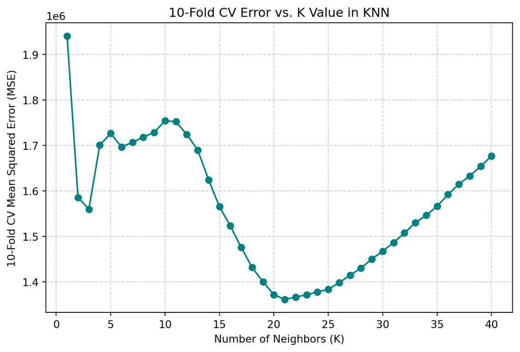

```
The optimal value for K is: 21
KNN (K=21) Test MSE: 1,361,781
KNN (K=21) Test RMSE: 1,167 bikes
```

```python
# Plotting the Cross-Validation MSE for different values of K
plt.figure(figsize=(8, 5))
plt.plot(Ks, cv_mse, marker='o', linestyle='-', color='teal')
plt.title('10-Fold CV Error vs. K Value in KNN')
plt.xlabel('Number of Neighbors (K)')
plt.ylabel('10-Fold CV Mean Squared Error (MSE)')
plt.xticks(np.arange(0, 45, step=5))
plt.grid(True, linestyle='--', alpha=0.6)
plt.show()

# Extract the best K mathematically
best_k = Ks[np.argmin(cv_mse)]
best_mse = np.min(cv_mse)
best_rmse = np.sqrt(best_mse)

print(f"The optimal value for K is: {best_k}")
print(f"KNN (K={best_k}) Test MSE: {best_mse:,.0f}")
print(f"KNN (K={best_k}) Test RMSE: {best_rmse:,.0f} bikes")
```

# 5 Task 5

**Question**: *Argue whether there are indications of nonlinear relationships between cnt and one or more predictors. Fit a flexible model, such as a generalized additive model (GAM), smoothing spline, or regression tree. Evaluate the predictive performance and compare it with earlier models.*

## 5.1 Indications of Non-Linearity and Model Selection

Throughout this analysis, there are indications of non-linear relationships between daily bike rentals and our predictors. in Task 2, we saw that introducing a degree-2 polynomial for our continuous variables (like temperature) significantly reduced our Test RMSE from 822 down to 741. This makes intuitive sense: as the temperature rises from freezing, bike rentals predictably increase, but if the weather becomes overwhelmingly hot, rentals will naturally drop off. A standard multiple linear regression model completely fails to capture this curve because it assumes a constant, straight-line slope.

To model these non-linearities, the course material suggests flexible models like Generalized Additive Models (GAMs), smoothing splines, or regression trees. While GAMs are excellent, they require installing additional non-standard packages in Python. From a practical standpoint, I argue that a Decision Tree Regressor is the best approach here. It is built natively into `scikit-learn`, making the code creation simple and efficient. More importantly, it provides an excellent trade-off between flexibility and interpretability. Instead of forcing complex mathematical curves, a tree simply asks a series of logical Yes/No questions to split the data (e.g., “Is the temperature > 20°C?” followed by “Is it raining?”). This allows the tree to naturally capture both non-linear effects and interactions between variables. Furthermore, because trees perform built-in feature selection, this model should help us completely bypass the “curse of dimensionality” that negatively impacted our KNN model in Task 4.

## 5.2 Fitting and Evaluating the Regression Tree

```python
# Initialize the Decision Tree Regressor
# We restrict max_depth to 5 to prevent the tree from growing too large and overfitting (high variance)
tree_model = DecisionTreeRegressor(max_depth=5, random_state=123)

# Fit the model on the standard training data
tree_model.fit(X_train, y_train)

# Predict on the unseen test data
y_pred_tree = tree_model.predict(X_test)

# Calculate Test MSE and RMSE
mse_tree = mean_squared_error(y_test, y_pred_tree)
rmse_tree = np.sqrt(mse_tree)

print(f"Regression Tree (max_depth=5) Test MSE: {mse_tree:,.0f}")
print(f"Regression Tree (max_depth=5) Test RMSE: {rmse_tree:,.0f} bikes")
```

```
Regression Tree (max_depth=5) Test MSE: 924,564
Regression Tree (max_depth=5) Test RMSE: 962 bikes
```

## 5.3 Discussion of Findings and Reflection

The Decision Tree achieved a Test RMSE of 962 bikes. Interestingly, this performs noticeably worse than both our simple OLS model (822) and our Polynomial model (741).

Here is a reflection on this finding: from a theoretical standpoint, single trees are known to suffer from high variance and can be quite step-like and rigid. Since the true relationship between weather conditions (like temperature) and biking is likely a smooth, continuous curve, it makes sense that our polynomial model captured it better than the blocky splits of a tree.

Beyond the algorithm itself, this result makes me reflect on whether we should have been much stricter with our feature selection in Task 1. Our dataset only has about 730 rows (two years of daily data). By converting qualitative variables into numerous dummy variables, we significantly increased our dimensionality relative to our sample size. We might have been too lenient in keeping variables without doing more formal testing—such as dropping variables with very low regression coefficients or correlations—to justify their inclusion.

The most low-hanging fruit here is our choice of categorical variables. We kept `mnth` (12 categories) instead of the broader `season` (4 categories). Intuitively, summer as a broad concept is a great indicator for bike rentals. By keeping specific months, we may have inadvertently given the tree room to capture unrelated, isolated events (like a randomly rainy July week in 2011) that damaged its ability to generalize to new data. Similarly, we kept `weekday` instead of `workingday`. It doesn’t really make logical sense that a Thursday would have a drastically different underlying effect than a Tuesday, all else being equal. Using a simple `workingday` binary might have been a much cleaner, more robust indicator. Ultimately, taking a more careful, aggressive approach to feature selection early on could have paved the way for better model performance across both our Tree and KNN models.